### Nombre: Jorge Arévalo

### Docente: Ing. Diego Quisi

### Materia: Simulación

# Covid-19 infección en Ecuador. Modelos matemáticos y predicciones

Una comparación de modelos, lineal, polilnomico,logísticos y exponenciales aplicados a la infección por el virus Covid-19

Se realiza un análisis matemático simple del crecimiento de la infección en Python y dos modelos para comprender mejor la evolución de la infección.

Se crea modelos de series temporales del número total de personas infectadas hasta la fecha (es decir, las personas realmente infectadas más las personas que han sido infectadas). Estos modelos tienen parámetros , que se estimarán por ajuste de curva.

```python
# Importar las librerias para el analasis
import pandas as pd
import numpy as np
from datetime import datetime,timedelta
from sklearn.metrics import mean_squared_error
from scipy.optimize import curve_fit
from scipy.optimize import fsolve
from sklearn import linear_model
import matplotlib.pyplot as plt
%matplotlib inline
```

```python
# Actualizar los datos (URL)

url = 'http://cowid.netlify.com/data/full_data.csv'

df = pd.read_csv(url)
df
```

|  | date | location | new_cases | new_deaths | total_cases | total_deaths |
| --- | --- | --- | --- | --- | --- | --- |
| 0 | 2020-02-25 | Afghanistan | NaN | NaN | 1 | NaN |
| 1 | 2020-02-26 | Afghanistan | 0.0 | NaN | 1 | NaN |
| 2 | 2020-02-27 | Afghanistan | 0.0 | NaN | 1 | NaN |
| 3 | 2020-02-28 | Afghanistan | 0.0 | NaN | 1 | NaN |
| 4 | 2020-02-29 | Afghanistan | 0.0 | NaN | 1 | NaN |
| ... | ... | ... | ... | ... | ... | ... |
| 2862 | 2020-03-13 | World | 7488.0 | 338.0 | 132758 | 4956.0 |
| 2863 | 2020-03-14 | World | 9761.0 | 433.0 | 142534 | 5392.0 |
| 2864 | 2020-03-15 | World | 10967.0 | 343.0 | 153517 | 5735.0 |
| 2865 | 2020-03-16 | World | 13971.0 | 855.0 | 167506 | 6606.0 |
| 2866 | 2020-03-17 | World | 11594.0 | 819.0 | 179112 | 7426.0 |

2867 rows × 6 columns

Imprimos los resultados y agregamos el numero del dia

```python
df = df[df['location'].isin(['Ecuador'])] #Filtro la Informacion solo para Ecuador
df = df.loc[:,['date','total_cases']] #Selecciono las columnas de analasis
# Expresar las fechas en numero de dias desde el 01 Enero
FMT = '%Y-%m-%d'
date = df['date']
df['date'] = date.map(lambda x : (datetime.strptime(x, FMT) - datetime.strptime("2020-01-01", FMT)).days)

df
```

|  | date | total_cases |
| --- | --- | --- |
| 681 | 60 | 1 |
| 682 | 61 | 1 |
| 683 | 62 | 6 |
| 684 | 63 | 7 |
| 685 | 64 | 7 |
| 686 | 65 | 13 |
| 687 | 66 | 14 |
| 688 | 67 | 14 |
| 689 | 68 | 15 |
| 690 | 69 | 15 |
| 691 | 70 | 15 |
| 692 | 71 | 17 |
| 693 | 72 | 17 |
| 694 | 73 | 23 |
| 695 | 74 | 23 |
| 696 | 75 | 37 |
| 697 | 76 | 58 |

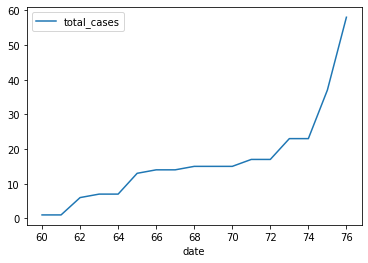

```python
df.plot(x ='date', y='total_cases')
```

## EL modelo lineal

La regresión lineal es un algoritmo de aprendizaje supervisado que se utiliza en Machine Learning y en estadística. En su versión más sencilla, lo que haremos es «dibujar una recta» que nos indicará la tendencia de un conjunto de datos continuos.

Recordemos rápidamente la fórmula de la recta:

Y = mX + b

Donde Y es el resultado, X es la variable, m la pendiente (o coeficiente) de la recta y b la constante o también conocida como el «punto de corte con el eje Y» en la gráfica (cuando X=0) Ejemplo

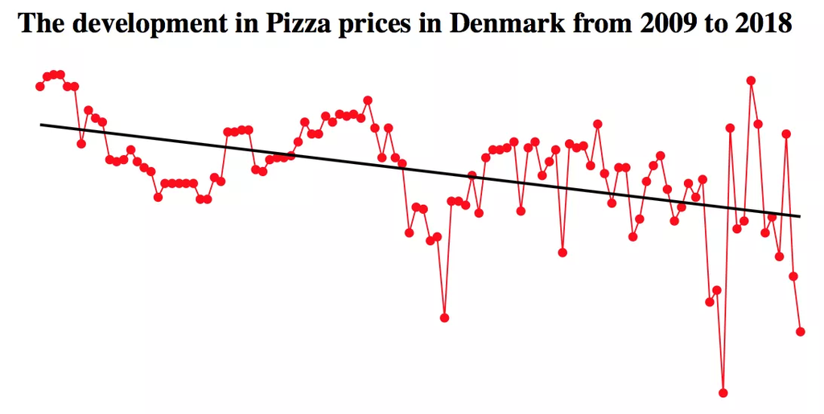

Recordemos que los algoritmos de Machine Learning Supervisados, aprenden por sí mismos y -en este caso- a obtener automáticamente esa «recta» que buscamos con la tendencia de predicción. Para hacerlo se mide el error con respecto a los puntos de entrada y el valor «Y» de salida real.

```python
x = list(df.iloc [:, 0]) # Fecha
y = list(df.iloc [:, 1]) # Numero de casos
# Creamos el objeto de Regresión Lineal
regr = linear_model.LinearRegression()

# Entrenamos nuestro modelo
regr.fit(np.array(x).reshape(-1, 1) ,y)

# Veamos los coeficienetes obtenidos, En nuestro caso, serán la Tangente
print('Coefficients: \n', regr.coef_)
# Este es el valor donde corta el eje Y (en X=0)
print('Independent term: \n', regr.intercept_)
# Error Cuadrado Medio
```

```
Coefficients:
 [2.31617647]
Independent term:
 -140.85294117647058
```

De la ecuación de la recta y = mX + b nuestra pendiente «m» es el coeficiente y el término independiente «b»

```python
#Vamos a comprobar:
# Quiero predecir cuántos "Casos" voy a obtener por en el dia 100,
# según nuestro modelo, hacemos:
y_prediccion = regr.predict([[100]])
print(int(y_prediccion))
```

```
90
```

```
[50 51 52 53 54 55 56 57 58 59 60 61 62 63 64 65 66 67 68 69 70 71 72 73
 74 75 76 77 78 79 80 81 82 83 84 85 86 87 88 89 90 91 92 93 94 95 96 97
 98 99]
```

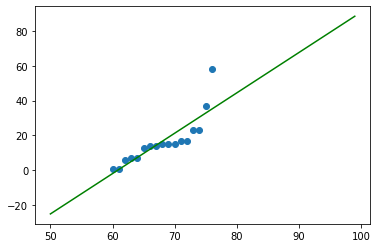

```python
#Graficar
plt.scatter(x, y)
x_real = np.array(range(50, 100))
print(x_real)
plt.plot(x_real, regr.predict(x_real.reshape(-1, 1)), color='green')
plt.show()
```